#### Dragos Ailoae

2021-11-22

# Part 2

### 3. Examination of the statistical assumptions needed for correct interpretation of the output

If we collect all of the various problems that can arise - we can rank them in terms of severity roughly as:

$$\text { outliers }>\text { non }-\text { linearity }> \text { heteroskedasticity }>\text { autocorrelation } >\text { non }-\text { normality }$$

In terms of impact on OLS estimation:

\begin{array}{lcccc} \hline \text { Problem } & \text { Biased } \hat\beta & \text { Biased } S E & \text { Invalid } t / F & \text { Hi Var } \\ \hline \text { Non-linear } & \text { Yes } & \text { Yes } & \text { Yes } & - \\ \text { Heteroscedasticity } & \text { No } & \text { Yes } & \text { Yes } & \text { Yes } \\ \text { Autocorrealtion } & \text { No } & \text { Yes } & \text { Yes } & \text { Yes } \\ \text { Non-normal error } & \text { No } & \text { No } & \text { Yes } & \text { Yes } \\ \text { Multicollinearity } & \text { No } & \text { No } & \text { No } & \text { Yes } \\ \text { Omit relevant } X & \text { Yes } & \text { Yes } & \text { Yes } & - \\ \text { Irrelevant } X & \text { No } & \text { No } & \text { No } & \text { Yes } \\ X \text { measurement Error } & \text { Yes } & \text { Yes } & \text { Yes } & - \\ \hline \end{array}

### 3.1 Non-linearity

One of the most critical assumptions of OLS is that the relationships between variables are linear in their functional form.

To motivate the upcomming test procedure, consider the following example - assume that the true model is quadratic: $$ Y_{i}=\beta_{0}+\beta_{1} X_{i}^{2}+\epsilon_{i}, \text { where } X_{i} \sim \mathcal{N}(1,1), \epsilon_{i} \sim \mathcal{N}\left(0,0.5^{2}\right) $$

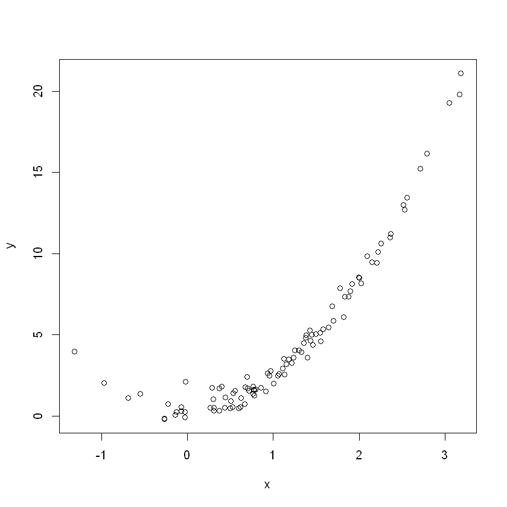

```r
rm(list=ls())    # Removes all items in Environment!
options(warn=-1) # Suppress warnings
#options(repr.plot.width = 7, repr.plot.height = 7)  # plot size
qui <- suppressPackageStartupMessages # quiet! - suppress library load messages

set.seed(123)
#
N = 100
beta_vec <- c(0.5, 2)
#
x <- rnorm(mean = 1, sd = 1, n = N)
e <- rnorm(mean = 0, sd = 0.5, n = N)
y <- cbind(1, x^2) %*% beta_vec + e

plot(x, y)
```

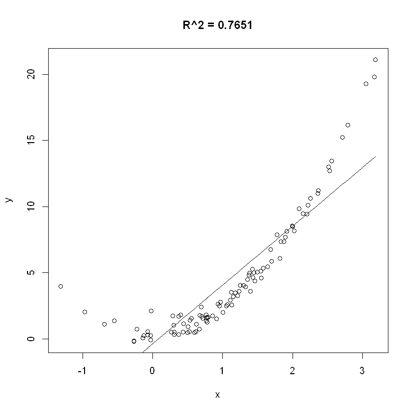

```r
mdl_temp <- lm(y ~ x)

plot(x, y, main = paste0("R^2 = ", round(summary(mdl_temp)$r.squared, 4)))
lines(x[order(x)], mdl_temp$fitted.values[order(x)])
```

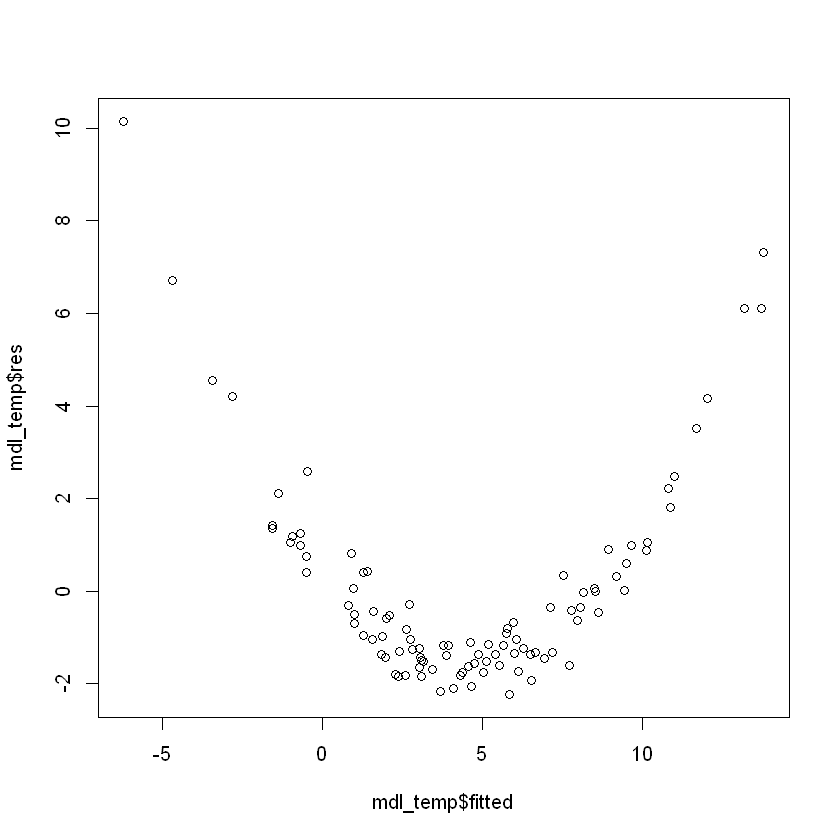

```r
plot(mdl_temp$fitted, mdl_temp$res)
```

One solution to the non-linearity problem is polinomial regression. We can think of the polynomial model as the Taylor series expansion of the unknown function. https://en.wikipedia.org/wiki/Taylor_series.

Polynomial models are useful:  
• in situations where the analyst knows that curvilinear effects are present in the true response function  
• as approximating functions to unknown and possibly very complex nonlinear relationships.

```
Call:
lm(formula = y ~ x + I(x^2))

Residuals:
     Min       1Q   Median       3Q      Max
-0.96841 -0.36457 -0.05954  0.32720  1.66598

Coefficients:
            Estimate Std. Error t value Pr(>|t|)
(Intercept)  0.45592    0.07802   5.844 6.83e-08 ***
x            0.07348    0.11081   0.663    0.509
I(x^2)       1.95540    0.04342  45.035  < 2e-16 ***
---
Signif. codes:  0 '***' 0.001 '**' 0.01 '*' 0.05 '.' 0.1 ' ' 1

Residual standard error: 0.4852 on 97 degrees of freedom
Multiple R-squared:  0.9893,	Adjusted R-squared:  0.9891
F-statistic:  4476 on 2 and 97 DF,  p-value: < 2.2e-16
```

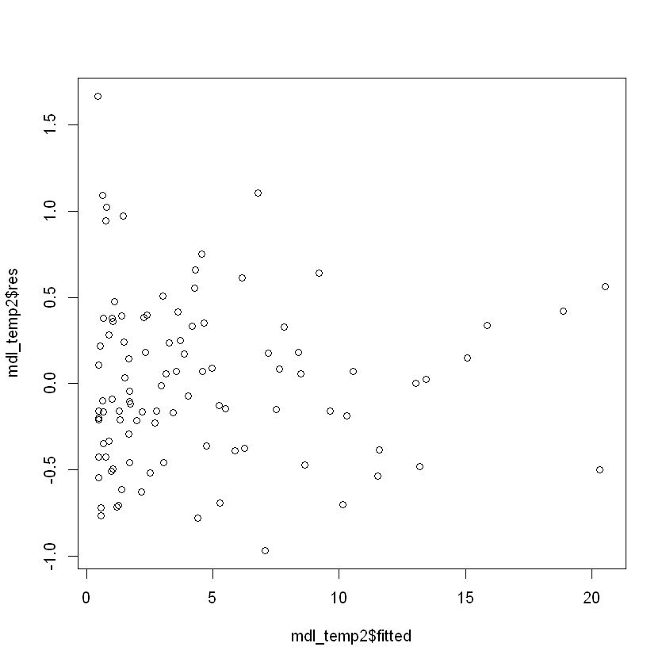

```r
mdl_temp2 <- lm(y ~ x + I(x^2))
plot(mdl_temp2$fitted, mdl_temp2$res)
summary(mdl_temp2)
```

After including polynomical term the residuals look more like white noise.

In a multiple regression it is more difficult to identify the nonlinear response variable and it's best to plot the residuals against each dependent variable. Getting back to our climate change perceptions model:

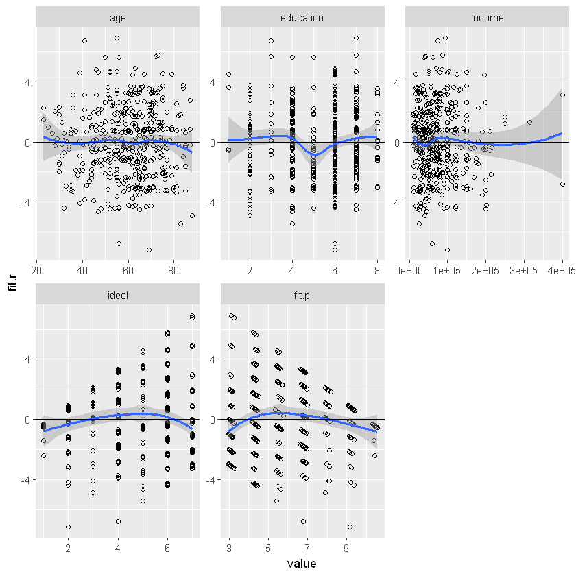

```r
# install (if not already installed) and load package
qui(if(!require(knitr)){install.packages('knitr')})         # for kable() - table formatting
qui(if(!require(tidyverse)){install.packages('tidyverse')}) # for pipes
qui(if(!require(modelsummary)){install.packages('modelsummary')})  #datasummary_skim(), modelsummary(), datasummary_correlation()
qui(if(!require(reshape2)){install.packages('reshape2')}) # for melt()

ds <- read.csv("https://ciresar.github.io/NYU/Lab_10/lab_10_dataset_1.csv")

ds.small <- filter(ds) %>%
  dplyr::select("glbcc_risk", "age", "education", "income", "ideol") %>%
  slice(1:500)
ds.small <- ds.small %>% drop_na()   # filter out N/As
rownames(ds.small) <- 1:nrow(ds.small) # reindex dataframe without the missing values
ols1 <-  lm(glbcc_risk ~ age + education + income + ideol, data = ds.small)

ds.small$fit.r <- ols1$residuals
ds.small$fit.p <- ols1$fitted.values

ds.small %>%
  melt(measure.vars = c("age", "education", "income", "ideol", "fit.p")) %>%
  ggplot(aes(value, fit.r, group = variable)) +
  geom_point(shape = 1) +
  geom_smooth(method = loess) +
  geom_hline(yintercept = 0) +
  facet_wrap(~ variable, scales = "free")
```

As we can see, the plots of residuals by both income and ideology seem to indicate non-linear relationships. We can check this visual analysis by squaring each term and using the ANOVA function for an F-test to compare model fit.

```r
ds.small$age2 <- ds.small$age^2
ds.small$edu2 <- ds.small$education^2
ds.small$inc2 <- ds.small$income^2
ds.small$ideology2<-ds.small$ideol^2
ols2 <- lm(glbcc_risk ~ age+age2+education+edu2+income+inc2+ideol+ideology2, data=ds.small)
summary(ols2)
```

```
Call:
lm(formula = glbcc_risk ~ age + age2 + education + edu2 + income +
    inc2 + ideol + ideology2, data = ds.small)

Residuals:
    Min      1Q  Median      3Q     Max
-7.1563 -1.5894  0.0389  1.4898  7.3417

Coefficients:
              Estimate Std. Error t value Pr(>|t|)
(Intercept)  9.661e+00  1.931e+00   5.004 8.12e-07 ***
age          2.973e-02  5.735e-02   0.518 0.604385
age2        -2.891e-04  5.010e-04  -0.577 0.564175
education   -4.814e-01  3.589e-01  -1.341 0.180499
edu2         5.132e-02  3.722e-02   1.379 0.168723
income       2.853e-06  5.341e-06   0.534 0.593564
inc2        -1.131e-11  1.839e-11  -0.615 0.538966
ideol       -5.726e-02  3.532e-01  -0.162 0.871279
ideology2   -1.327e-01  3.965e-02  -3.347 0.000886 ***
---
Signif. codes:  0 '***' 0.001 '**' 0.01 '*' 0.05 '.' 0.1 ' ' 1

Residual standard error: 2.33 on 441 degrees of freedom
Multiple R-squared:  0.4528,	Adjusted R-squared:  0.4429
F-statistic: 45.61 on 8 and 441 DF,  p-value: < 2.2e-16
```

The model output indicates that ideology may have a non-linear relationships with risk perceptions of climate change. For ideology, only the squared term is significant, indicating that levels of perceived risk of climate change decline at an increasing rate for those on the most conservative end of the scale. Again, this is consistent with the visual inspection of the relationship between ideology and the residuals in the figure. The question remains whether the introduction of these non-linear (polynomial) terms improves overall model fit. We can check that with an analysis of variance across the simple model (without polynomial terms) and the models with the squared terms.

```r
anova(ols1,ols2)
```

A anova: 2 × 6

|  | Res.Df <dbl> | RSS <dbl> | Df <dbl> | Sum of Sq <dbl> | F <dbl> | Pr(>F) <dbl> |
| --- | --- | --- | --- | --- | --- | --- |
| 1 | 445 | 2464.247 | NA | NA | NA | NA |
| 2 | 441 | 2393.188 | 4 | 71.05883 | 3.273556 | 0.01160913 |

As we can see, the ANOVA test indicates that including the squared terms improves model fit, therefore the relationships include nonlinear components.

```r
qui(if(!require(lmtest)){install.packages('lmtest')}) # for resettest()
resettest(ols1,power=2:3,type="regressor")
```

```
	RESET test

data:  ols1
RESET = 2.2752, df1 = 8, df2 = 437, p-value = 0.02157
```

Again, the test provides evidence that we have a non-linear relationship (i.e. we reject the null hypothesis that the restricted model - the one without polynomial terms- is a better fit.

What should we do when we identify a nonlinear relationship between our $Y$ and $X$ s? The first step is to look closely at the bi-variate plots, to try to discern the correct functional form for each $X$ regressor. If the relationship looks curvilinear, try a polynomial regression in which you include both $X$ and $X^{2}$ for the relevant independent variables. It may also be the case that a skewed dependent or independent variables is causing the problem. This is not unusual when, for example, the income variable plays an important role in the model, and the distribution of income is skewed upward. In such a case, you can try transforming the skewed variable, using an appropriate log form.

It is possible that variable transformations won't suffice, however. In that case, you may have no other option by to try non-linear forms of regression.

### 3.2 Heteroskedastic errors

The case when the error variance-covariance matrix is diagonal, but not equal to $\sigma_{\epsilon}^{2} \mathbf{I}$, expressed as: $$ \boldsymbol{\Sigma}=\left[\begin{array}{ccccc} \sigma_{1}^{2} & 0 & 0 & \ldots & 0 \\ 0 & \sigma_{2}^{2} & 0 & \ldots & 0 \\ \vdots & \vdots & \vdots & \ddots & \vdots \\ 0 & 0 & 0 & \ldots & \sigma_{N}^{2} \end{array}\right] $$ is referred to as heteroskedasticity.

As mentioned in the summary table above, under heteroskedasticity:

- the OLS estimators will remain unbiased;
- the OLS variance estimator is biased and inconsistent;
- the usual $t$-statistics of the OLS estimates do not have Student's $t$ distribution, even in large samples.

Let's simulate the following model: $$ \begin{aligned} &Y_{i}=\beta_{0}+\beta_{1} X_{1, i}+\beta_{2} X_{2, i}+u_{i} \\ &u_{i}=i \cdot \epsilon_{i}, \quad \epsilon_{i} \sim \mathcal{N}\left(0, \sigma^{2}\right) \quad\left[\text { or } u_{i} \sim \mathcal{N}\left(0, i^{2} \cdot \sigma^{2}\right)\right] \end{aligned} $$

```r
set.seed(123)
#
N <- 200
beta_vec <- c(10, 5, -3)
#
x1 <- seq(from = 0, to = 5, length.out = N)
x2 <- sample(seq(from = 3, to = 17, length.out = 80), size = N, replace = TRUE)
e  <- rnorm(mean = 0, sd = 1:N, n = N)
#
x_mat <- cbind(1, x1, x2)
#
y <- x_mat %*% beta_vec + e
#
data_mat <- data.frame(y, x1, x2)
```

We can examine the presence of heteroskedasticity from the residuals plots, as well as conducting a number of formal tests.

We will begin by estimating our model via OLS, as we usually would.

```r
mdl_1 <- lm(y ~ x1 + x2, data = data_mat)
print(round(coef(summary(mdl_1)), 5))
```

```
            Estimate Std. Error  t value Pr(>|t|)
(Intercept) -0.89066   28.42373 -0.03134  0.97503
x1           7.21929    5.93429  1.21654  0.22524
x2          -1.83213    2.18885 -0.83703  0.40359
```

One way of investigating the existence of heteroskedasticity is to visually examine the OLS model residuals. If they are homoskedastic, there should be no pattern in the residuals. If the errors are heteroskedastic, they would exhibit increasing or decreasing variation in some systematic way. For example, variation may increase with larger values of $\widehat{Y}$, or with larger values of $X_{j}$.

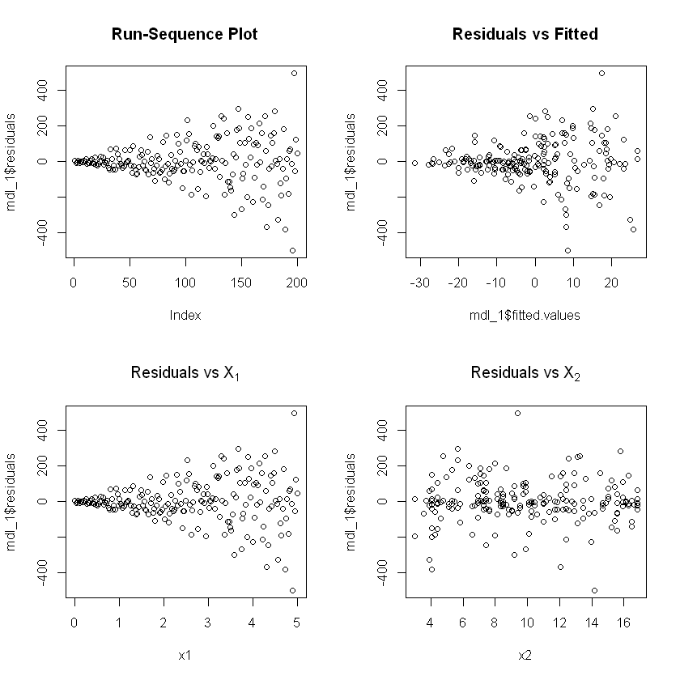

```r
par(mfrow = c(2, 2))
plot(mdl_1$residuals, main = "Run-Sequence Plot")
plot(mdl_1$fitted.values, mdl_1$residuals, main = "Residuals vs Fitted")
plot(x1, mdl_1$residuals, main = bquote("Residuals vs"~X[1]))
plot(x2, mdl_1$residuals, main = bquote("Residuals vs"~X[2]))
```

```r
BP_t <- lmtest::bptest(mdl_1)
print(BP_t)
```

```
	studentized Breusch-Pagan test

data:  mdl_1
BP = 35.896, df = 2, p-value = 1.604e-08
```

The p-value is less than the chosen 0.05 significance level, so the residuals are heteroskedastic.

There are several steps that can be considered when confronted by heteroskedasticity in the residuals. First, we can consider whether we need to re-specify the model, possibly because we have some omitted variables. If model re-specification does not correct the problem, we can use non-OLS regression techniques that include robust estimated standard errors. Robust standard errors are appropriate when error variance is unknown.

```r
dt_hce_se <- NULL
for(hc_type in c("HC0", "HC1", "HC2", "HC3")){
    dt_hce_se <- cbind(dt_hce_se, lmtest::coeftest(mdl_1,
                                                   vcov. = sandwich::vcovHC(mdl_1, type = hc_type))[, 2])
}
dt_hce_se <- cbind(dt_hce_se, coef(summary(mdl_1))[, 2])
colnames(dt_hce_se) <- c("HC0", "HC1", "HC2", "HC3", "OLS")
print(round(dt_hce_se, 6))
```

```
                  HC0       HC1       HC2       HC3       OLS
(Intercept) 26.329663 26.529386 26.599218 26.872079 28.423734
x1           6.824231  6.875996  6.894074  6.964745  5.934290
x2           2.179232  2.195763  2.201433  2.223901  2.188846
```

Let's say we settle on HC3:

```r
print(lmtest::coeftest(mdl_1, vcov. = sandwich::vcovHC(mdl_1, type = "HC3")))
```

```
t test of coefficients:

            Estimate Std. Error t value Pr(>|t|)
(Intercept) -0.89066   26.87208 -0.0331   0.9736
x1           7.21929    6.96475  1.0365   0.3012
x2          -1.83213    2.22390 -0.8238   0.4110
```

Despite these adjustments, the results on the coefficients' significance remain unchanged.

It is important to note that, while robust estimators can help atone for heteroscedasticity in your models, their use should not be seen as an alternative to careful model construction. The first step should always be to evaluate your model specification and functional form (e.g., the use of polynomials, inclusion of relevant variables), as well as possible measurement error, before resorting to robust estimation.

**Weighted Least Squares**

A more involved alternative is to model the heteroskedasticity and weigh the residuals accordingly. This method and the associated problems will be covered later in the course under (GLS).

```r
# estimate via WLS
resid_data <- data.frame(log_e2 = log(mdl_1$residuals^2), x1, x2)
h_est   <- exp(lm(log_e2 ~ x1 + x2, data = resid_data)$fitted.values)
mdl_wls <- lm(y ~ x1 + x2, data = data_mat, weights =  1 / h_est)
summary(mdl_wls)
```

```
Call:
lm(formula = y ~ x1 + x2, data = data_mat, weights = 1/h_est)

Weighted Residuals:
    Min      1Q  Median      3Q     Max
-4.5762 -1.3421 -0.0546  1.2794  5.9209

Coefficients:
            Estimate Std. Error t value Pr(>|t|)
(Intercept)  -1.3924    10.1948  -0.137   0.8915
x1            7.9764     4.0033   1.992   0.0477 *
x2           -2.0246     0.8816  -2.297   0.0227 *
---
Signif. codes:  0 '***' 0.001 '**' 0.01 '*' 0.05 '.' 0.1 ' ' 1

Residual standard error: 2.076 on 197 degrees of freedom
Multiple R-squared:  0.04577,	Adjusted R-squared:  0.03608
F-statistic: 4.724 on 2 and 197 DF,  p-value: 0.009906
```

### 3.3 Independence of $\epsilon$: Autocorrelated (Serially Correlated) Errors

The case when the error variance-covariance matrix is no longer diagonal, but with equal diagonal elements, expressed as: $$ \boldsymbol{\Sigma}=\left[\begin{array}{ccccc} \sigma^{2} & \sigma_{1,2} & \sigma_{1,3} & \ldots & \sigma_{1, N} \\ \sigma_{2,1} & \sigma^{2} & \sigma_{2,3} & \ldots & \sigma_{2, N} \\ \vdots & \vdots & \vdots & \ddots & \vdots \\ \sigma_{N, 1} & \sigma_{N, 2} & \sigma_{N 3,} & \ldots & \sigma^{2} \end{array}\right], \quad \sigma_{i, j}=\sigma_{j, i}=\mathbb{C o v}\left(\epsilon_{i}, \epsilon_{j}\right) \neq 0, \quad i, j=1, \ldots, N $$ is referred to as autocorrelation (or serial correlation). Just like before with heteroskedasticity:

- the OLS estimators remain unbiased and consistent;
- OLS estimators are no longer efficient;
- the variance estimator of the OLS estimates is biased and inconsistent;
- $t$-statistics of the OLS estimates are invalid. It should be stressed that serial correlation is usually present in time-series data. For cross-sectional data, the errors may be correlated in terms of social, or geographical distance. For example, the distance between cities, towns, neighborhoods, etc.

To gain some insight into the problem we will simulate the following model: $$ \left\{\begin{array}{l} Y_{i}=\beta_{0}+\beta_{1} X_{1, i}+\beta_{2} X_{2, i}+\epsilon_{i} \\ \epsilon_{i}=\rho \epsilon_{i-1}+u_{i},|\rho|<1, u_{i} \sim \mathcal{N}\left(0, \sigma^{2}\right), \quad \epsilon_{0}=0 \end{array}\right. $$

```r
set.seed(123)
#
N <- 200
beta_vec <- c(10, 5, -3)
rho <- 0.8
#
x1 <- seq(from = 0, to = 5, length.out = N)
x2 <- sample(seq(from = 3, to = 17, length.out = 80), size = N, replace = TRUE)
# serially correlated residuals:
ee <- rnorm(mean = 0, sd = 3, n = N)
for(i in 2:N){
  ee[i] <- rho * ee[i-1] + ee[i]
}
#
x_mat <- cbind(1, x1, x2)
#
y <- x_mat %*% beta_vec + ee
#
data_mat <- data.frame(y, x1, x2)
```

We can identify autocorrelation from the residuals plots or by conducting a number of formal statistical tests.

We will begin by estimating our model via OLS, as we usually would:

```r
mdl_1 <- lm(y ~ x1 + x2, data = data_mat)
summary(mdl_1)
```

```
Call:
lm(formula = y ~ x1 + x2, data = data_mat)

Residuals:
    Min      1Q  Median      3Q     Max
-9.7965 -3.2193  0.0674  2.5057 11.8135

Coefficients:
            Estimate Std. Error t value Pr(>|t|)
(Intercept) 10.61601    0.97983   10.84   <2e-16 ***
x1           4.89018    0.20457   23.91   <2e-16 ***
x2          -2.93686    0.07545  -38.92   <2e-16 ***
---
Signif. codes:  0 '***' 0.001 '**' 0.01 '*' 0.05 '.' 0.1 ' ' 1

Residual standard error: 4.182 on 197 degrees of freedom
Multiple R-squared:  0.9198,	Adjusted R-squared:  0.919
F-statistic:  1129 on 2 and 197 DF,  p-value: < 2.2e-16
```

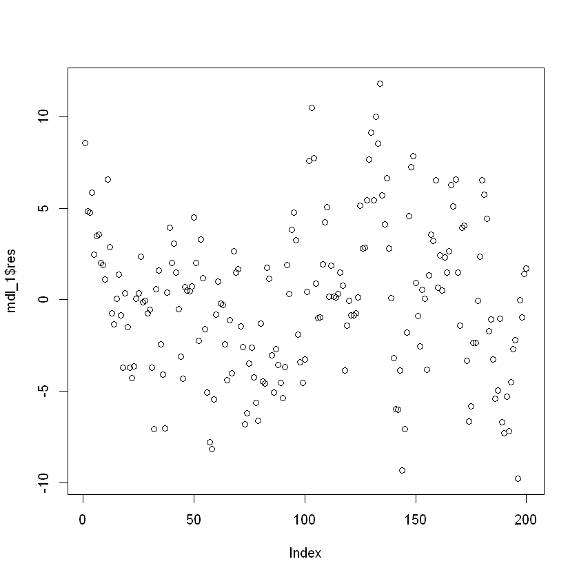

```r
plot(mdl_1$res)
```

The residuals plot show the telltale signs of autocorrelation. It is more obvious if we smooth the pattern:

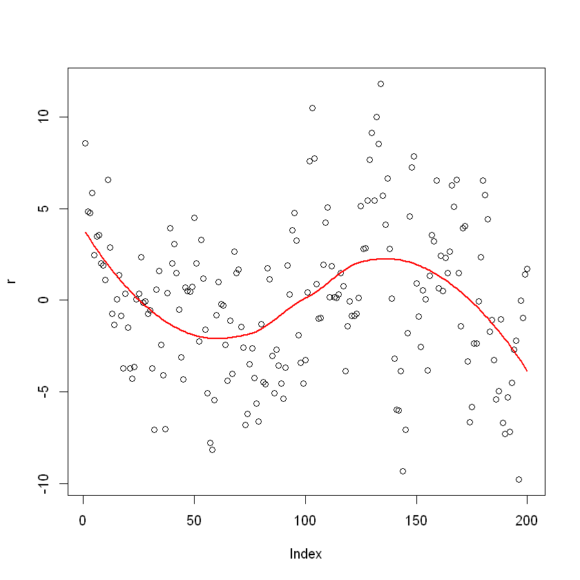

```r
r <- mdl_1$res
n<- 1:length(r)
plot(r)
lines(predict(loess(r~n)), col='red', lwd=2)
```

The sinusoidal pattern also shows up in the residuals [correlogram](https://en.wikipedia.org/wiki/Correlogram#:~:text=In%20the%20analysis%20of%20data,is%20called%20a%20cross%2Dcorrelogram.):

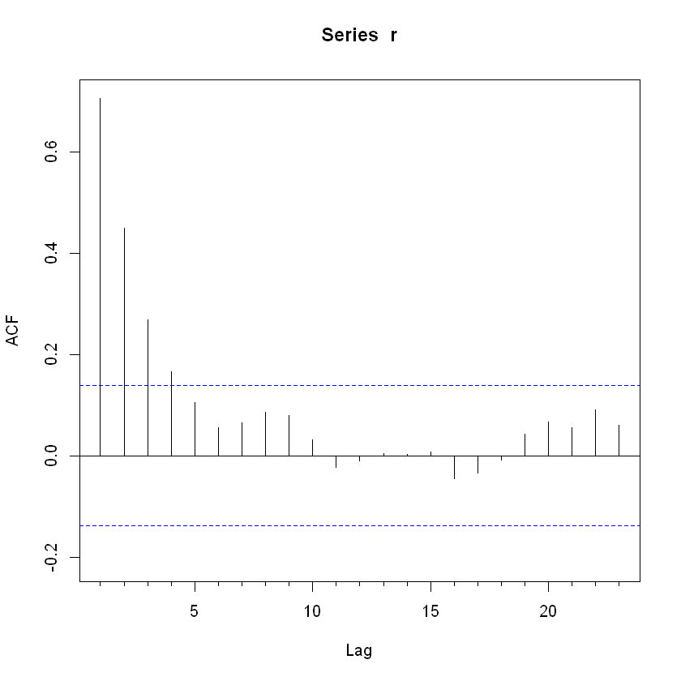

```r
qui(if(!require(forecast)){install.packages('forecast')}) # for Acf()
Acf(r)
```

Breusch-Godfrey (BG or LM) Test for autocorrelation.
$$\left\{\begin{array}{l}H_{0}: \rho_{1}=\ldots=\rho_{p}=0 \\ H_{1}: \rho_{j} \neq 0, \text { for some } j\end{array}\right.$$

```r
bg_t <- lmtest::bgtest(mdl_1, order = 3)
print(bg_t)
```

```
	Breusch-Godfrey test for serial correlation of order up to 3

data:  mdl_1
LM test = 100.72, df = 3, p-value < 2.2e-16
```

Since the $p$ - value $<0.05$, we reject the null hypothesis and conclude that there is serial correlation in the residuals.

If we find autocorrelation, we would need to respecify our model to account for (or estimate) the relationships among the error terms. In time series analysis, where observations are taken sequentially over time, we would typically include a "lag" term (in which the value of $Y$ in period $t$ is predicted by the value of $Y$ in period $t-1$ ). This is a typical $A R 1$ model, which would be discussed in a time-series analysis course. The entangled residuals can, of course, be much more complex, and require more specialized models (e.g., ARIMA or vectorautoregression models). These approaches will be studied next semester.

As a bandaid we may calculate heteroskedasticity-and-autocorrelation-consistent standard errors (HAC) to improve inferences.

```r
print(lmtest::coeftest(mdl_1, sandwich::vcovHAC(mdl_1)))
```

```
t test of coefficients:

             Estimate Std. Error  t value  Pr(>|t|)
(Intercept) 10.616005   1.165046   9.1121 < 2.2e-16 ***
x1           4.890185   0.413444  11.8279 < 2.2e-16 ***
x2          -2.936860   0.060834 -48.2769 < 2.2e-16 ***
---
Signif. codes:  0 '***' 0.001 '**' 0.01 '*' 0.05 '.' 0.1 ' ' 1
```

### 3.4 Normality Tests

The hypothesis that we want to test is: $$ \begin{cases}H_{0} & \text { : residuals follow a normal distribution } \\ H_{1} & \text { : residuals do not follow a normal distribution }\end{cases} $$ We will carry our the following tests and combine their $p$-values a single output:

```r
norm_tests.df = data.frame(Tests=c("Anderson-Darling",
              "Shapiro-Wilk",
              "Cramer-von Mises",
              "Jarque-Bera"))
norm_tests.df$p_vals <- c(nortest::ad.test(mdl_1$residuals)$p.value,
                shapiro.test(mdl_1$residuals)$p.value,
                nortest::cvm.test(mdl_1$residuals)$p.value,
                tseries::jarque.bera.test(mdl_1$residuals)$p.value)

# Rstudio output
# kable(norm_tests.df,digits=2, align="c", caption="Sample Correlation Matrix mdl_1","html")

# Jupyter output
kable(norm_tests.df,digits=2, align="c", caption="Sample Correlation Matrix mdl_1","html") %>%
 as.character  %>% IRdisplay::display_html()
```

Sample Correlation Matrix mdl_1

| Tests | p_vals |
| --- | --- |
| Anderson-Darling | 0.56 |
| Shapiro-Wilk | 0.55 |
| Cramer-von Mises | 0.56 |
| Jarque-Bera | 0.43 |

Compare this with our earlier model of the quadratic DGP:

```r
norm_tests.df = data.frame(Tests=c("Anderson-Darling",
              "Shapiro-Wilk",
              "Cramer-von Mises",
              "Jarque-Bera"))
norm_tests.df$p_vals <- c(nortest::ad.test(mdl_temp$residuals)$p.value,
                shapiro.test(mdl_temp$residuals)$p.value,
                nortest::cvm.test(mdl_temp$residuals)$p.value,
                tseries::jarque.bera.test(mdl_temp$residuals)$p.value)
# Rstudio output
# kable(norm_tests.df,digits=2, align="c", caption="Sample Correlation Matrix mdl_temp","html")

# Jupyter output
kable(norm_tests.df,digits=2, align="c", caption="Sample Correlation Matrix mdl_temp","html") %>%
 as.character  %>% IRdisplay::display_html()
```

Sample Correlation Matrix mdl_temp

| Tests | p_vals |
| --- | --- |
| Anderson-Darling | 0 |
| Shapiro-Wilk | 0 |
| Cramer-von Mises | 0 |
| Jarque-Bera | 0 |

According to all 4 tests we can reject the $Ho$ that residuals are normally distributed. This can also be confirmed by the quantile-quantile plots:

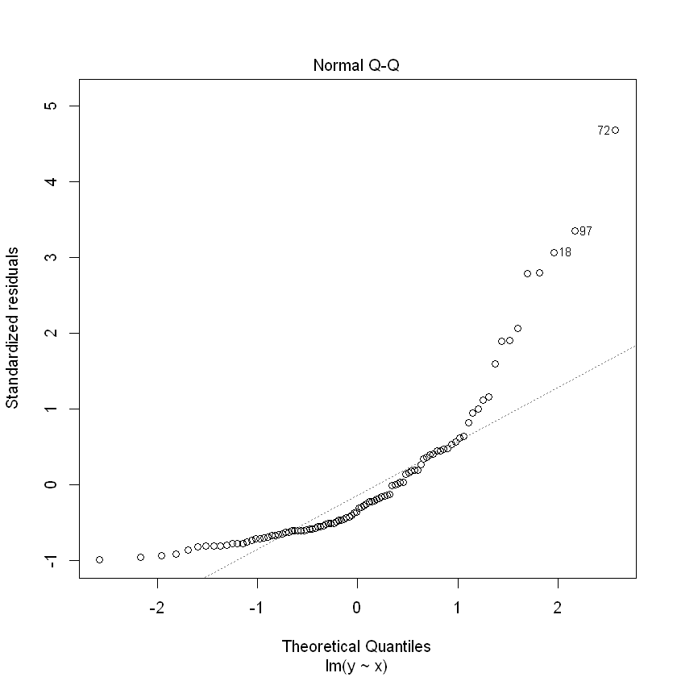

```r
plot(mdl_temp, 2)
```

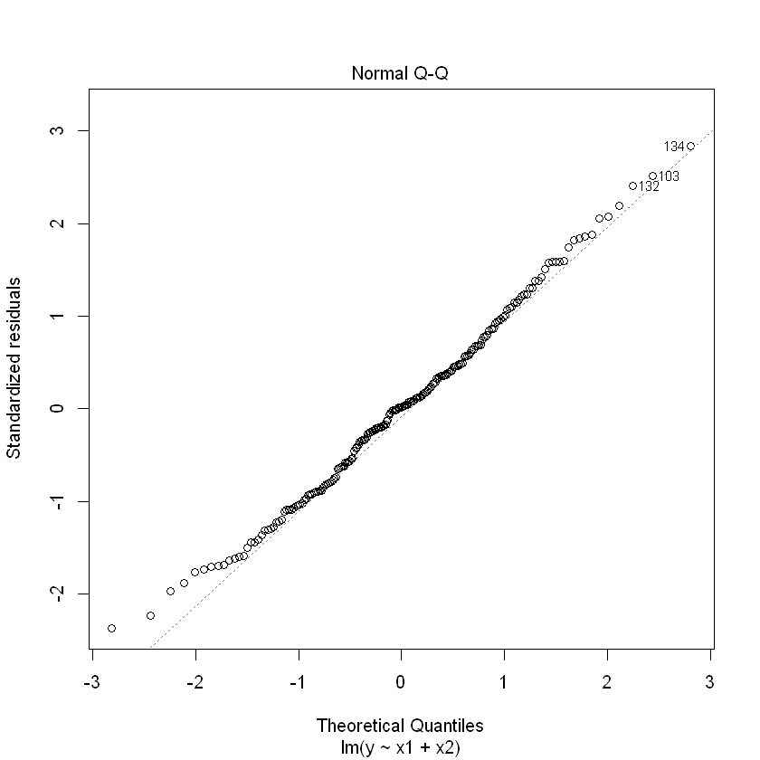

```r
plot(mdl_1,2)
```

### TLDR

R has a lot of different plots embedded in the default lm() function output. The examples above should help in understanding how to interpret these plots.

And here is how to view them:

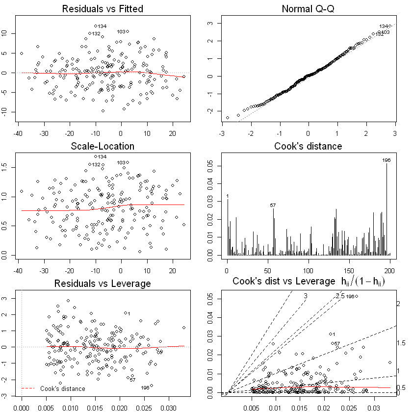

```r
par(mfrow = c(3, 2), mar = c(2, 2, 2, 2))
plot(mdl_1,1:6)
```

Or, to display an individual plot:

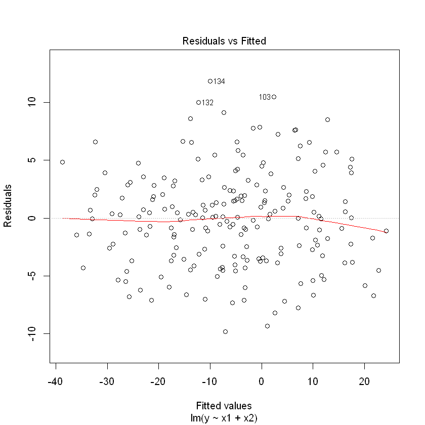

```r
plot(mdl_1,1)
```